# Advanced Statistical Modelling: Linear Models

Joel Cantero Priego and Ricard Meyerhofer Parra

12/10/2019

## Introduction

In this assignment, we are going to use the IMDB dataset. This IMDB dataset, contains information of 940 films released between 2000 and 2016. The data has been obtained from the IMDB’s webpage. The following is a list where we can see all the variables of the dataset:

| Variable name | Description | Values |
| --- | --- | --- |
| movietitle | Director of the given title | String |
| gross | Gross in dollars | Integer |
| budget | Budget in dollars | Integer |
| duration | Film duration in minutes | Integer |
| titleyear | The release year of the title | Integer |
| directorfl | Director Facebook likes | Integer |
| actor1fl | Actor 1 Facebook likes | Integer |
| actor2fl | Actor 2 Facebook likes | Integer |
| actor3fl | Actor 3 Facebook likes | Integer |
| castfl | Cast Facebook likes | Integer |
| facenumber_in_poster | Number of faces that appears in the poster | Integer |
| genre | Genre film | Action/Comedy/Drama/Terror |

As we can see we have that all our variables are numerical in exception genre. This dataset is complete which means that it has no missing values. However, this does not imply that there are no outliers.

As required in the assignment, we are going to create a categorical variable: **yearcat** which is the categorical substitution of titleyear with 3 levels: 2000-2005, 2006-2010 and 2011-2016. Therefore, we will have two categorical variables (genre and titleyear).

```r
dataset$yearcat<-cut(dataset$titleyear, c(2000,2005,2010,2016),
                   include.lowest = TRUE,
                   labels=c("2000-2005", "2006-2010", "2011-2016"))
```

We are going to scale the variables that are in dollars (budget and gross) so that our linear models perform better. This because the values in dollars are in a scale way bigger than the other variables which makes difficult to perform well for a linear model.

```r
#consider later when it increases that we have this variables in logarithm
#log G = bo + b1 log B + .....
#if we add one unit, we have to consider that we are in logarithm and we should express in exponential...
#is not the same if we consider without log and with log, so we have to consider.
#if we multiply per 10 is easier to later show.
dataset$gross <- log10(dataset$gross)
dataset$budget <- log10(dataset$budget)
```

## Exploratory Data Analysis

In this section we are going to focus in explaining the most interesting conclusions of our data, perform an univariate and multivariate analysis of the variables in order to find outliers and see the relationship and structure of the dataset variables.

### Univariate analysis

For univariate analysis, histograms and box plot were obtained for the numerical variables and bar charts were generated for the categorical variables.

We can see usual values for the Budget, with a mean of 40,484,550$.

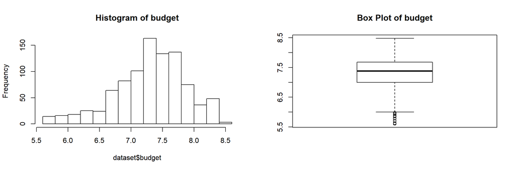

In duration film, we see that there is a certain tendency to normality centred around 100 minutes, we consider it as usual. There is a strange observation of 280 minutes for “Gods and General” film. After check it, we can say that it is not an error but an extrem value.

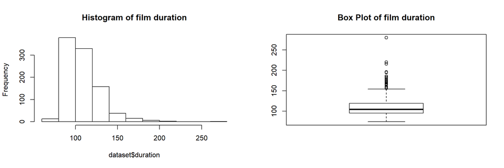

No problems for year, there is a certain expected balanced in years proportion.

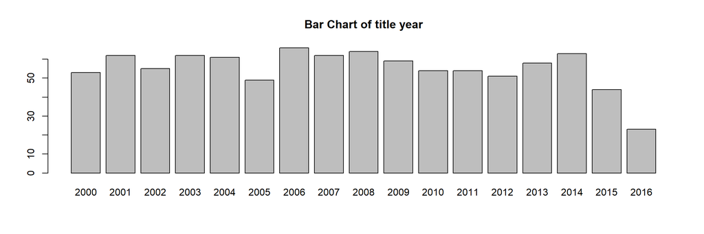

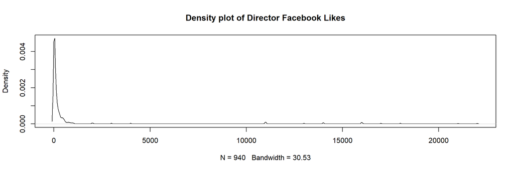

```
## [1] 0.1638298
```

[output not shown]

In face number in film poster, the mean is about 1,6 faces and we can observe an extrem value of 31 in “The Master”. We can say once again that it is not an error but an extrem value.

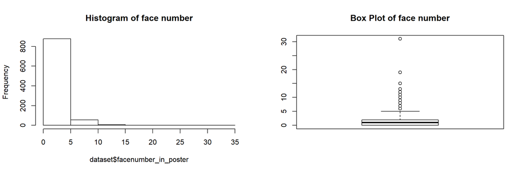

In genre film we can observe that there are more comedy and drama films than action and terror films.

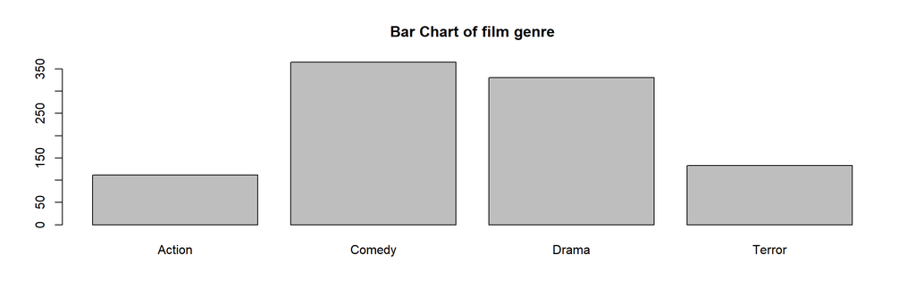

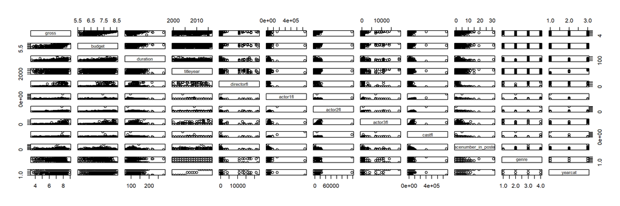

```r
# Gross variable exploration
summary(dataset$gross)
```

```
##    Min. 1st Qu.  Median    Mean 3rd Qu.    Max.
##   3.522   7.072   7.524   7.304   7.850   8.881
```

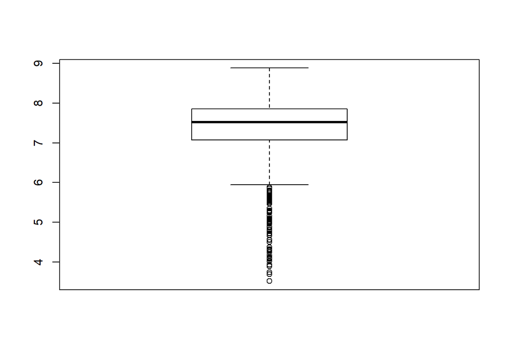

```r
boxplot(dataset$gross)
```

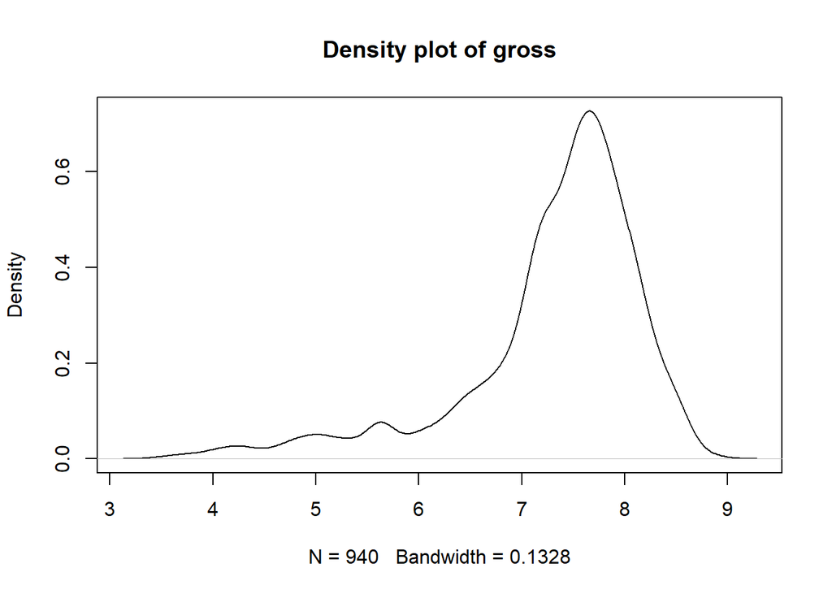

```r
plot(density(dataset$gross), main="Density plot of gross")
```

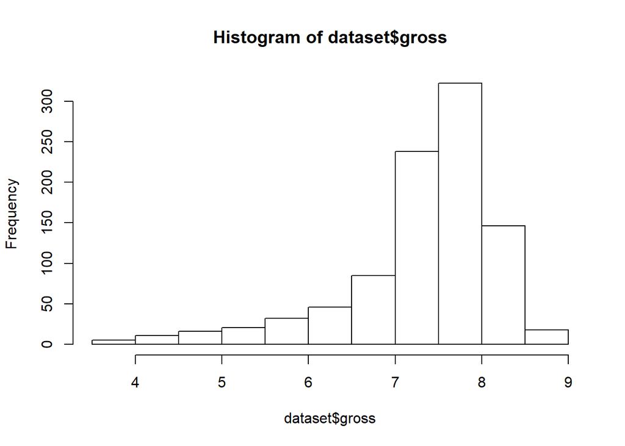

```r
#Histogram/Density Function
hist(dataset$gross)
```

```r
cat("Sample Mean\n")
```

```
## Sample Mean
```

```r
(m=mean(dataset$gross))
```

```
## [1] 7.303737
```

```r
cat("Sample Sd\n")
```

```
## Sample Sd
```

```r
(s=sd(dataset$gross))
```

```
## [1] 0.8880135
```

```r
cat("LogLik\n")
```

```
## LogLik
```

```r
(loglik=sum(log(dnorm(dataset$gross,mean=mean(dataset$gross),sd=sd(dataset$gross)))))
```

```
## [1] -1221.66
```

```r
cat("AIC\n")
```

```
## AIC
```

```r
(AIC=-2*loglik+2*2)
```

```
## [1] 2447.32
```

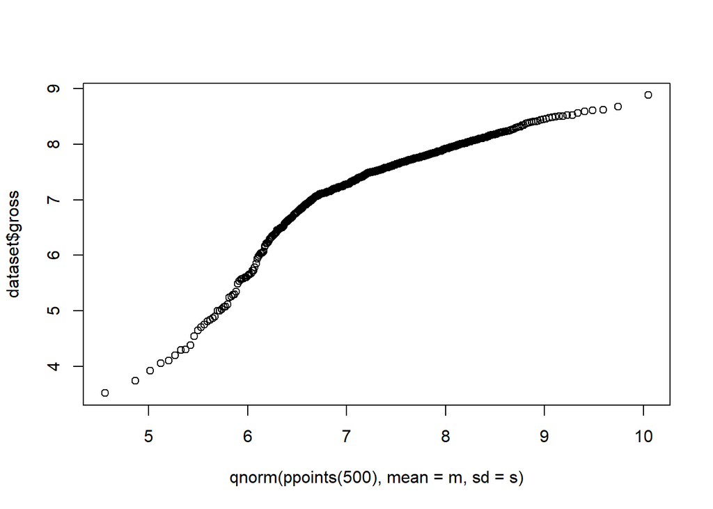

```r
#Plot Quantiles-Quantiles (Empirical-Theorical)
qqplot(qnorm(ppoints(500),mean=m,sd=s),dataset$gross)
```

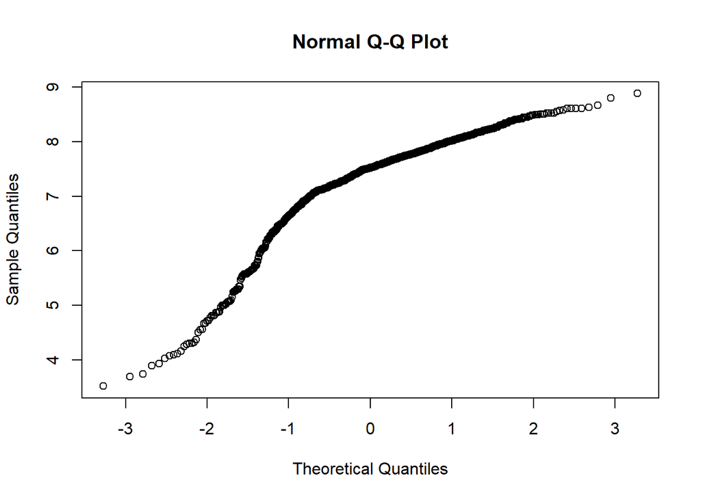

```r
qqnorm(dataset$gross)
```

The highest grossing film is Avatar (760,505,847$) and the lowest is Mi America (3330$).

## Fitting the complete model

```r
#Linear Regression
summary(m1<-lm(gross ~ budget + duration + titleyear + directorfl + actor1fl + actor2fl + actor3fl + castfl + facenumber_in_poster + genre, dataset))
```

```
##
## Call:
## lm(formula = gross ~ budget + duration + titleyear + directorfl +
##     actor1fl + actor2fl + actor3fl + castfl + facenumber_in_poster +
##     genre, data = dataset)
##
## Residuals:
##     Min      1Q  Median      3Q     Max
## -3.2988 -0.2709  0.0808  0.3631  2.1022
##
## Coefficients:
##                        Estimate Std. Error t value Pr(>|t|)
## (Intercept)          -8.055e+00  9.389e+00  -0.858   0.3912
## budget                1.058e+00  4.823e-02  21.941  < 2e-16 ***
## duration              2.522e-03  1.313e-03   1.920   0.0552 .
## titleyear             3.530e-03  4.666e-03   0.757   0.4495
## directorfl            5.607e-06  7.256e-06   0.773   0.4399
## actor1fl             -2.574e-05  1.867e-05  -1.379   0.1683
## actor2fl             -2.589e-05  1.940e-05  -1.335   0.1823
## actor3fl             -1.606e-05  3.131e-05  -0.513   0.6082
## castfl                2.574e-05  1.871e-05   1.376   0.1693
## facenumber_in_poster -1.183e-02  9.125e-03  -1.296   0.1953
## genreComedy           3.167e-01  8.062e-02   3.928 9.19e-05 ***
## genreDrama            1.264e-01  8.166e-02   1.548   0.1219
## genreTerror           4.803e-01  9.333e-02   5.147 3.24e-07 ***
## ---
## Signif. codes:  0 '***' 0.001 '**' 0.01 '*' 0.05 '.' 0.1 ' ' 1
##
## Residual standard error: 0.6456 on 927 degrees of freedom
## Multiple R-squared:  0.4782, Adjusted R-squared:  0.4714
## F-statistic: 70.79 on 12 and 927 DF,  p-value: < 2.2e-16
```

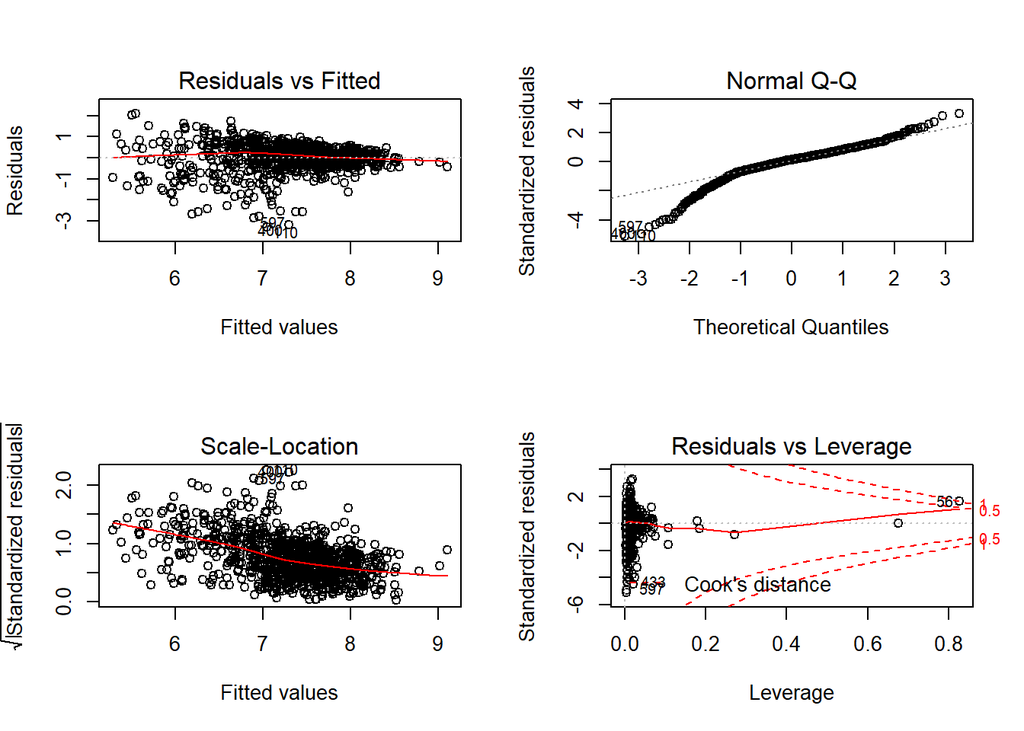

```r
op<-par(mfrow=c(2,2))
plot(m1)
```

```r
par(op)

summary(m2<-lm(gross ~ budget + duration + yearcat + directorfl + actor1fl + actor2fl + actor3fl + castfl + facenumber_in_poster + genre, dataset))
```

```
##
## Call:
## lm(formula = gross ~ budget + duration + yearcat + directorfl +
##     actor1fl + actor2fl + actor3fl + castfl + facenumber_in_poster +
##     genre, data = dataset)
##
## Residuals:
##     Min      1Q  Median      3Q     Max
## -3.1652 -0.2552  0.0829  0.3710  2.1596
##
## Coefficients:
##                        Estimate Std. Error t value Pr(>|t|)
## (Intercept)          -9.347e-01  3.539e-01  -2.641 0.008404 **
## budget                1.064e+00  4.780e-02  22.256  < 2e-16 ***
## duration              2.205e-03  1.303e-03   1.692 0.090900 .
## yearcat2006-2010     -1.765e-01  5.062e-02  -3.487 0.000511 ***
## yearcat2011-2016      4.854e-02  5.245e-02   0.925 0.354990
## directorfl            6.145e-06  7.185e-06   0.855 0.392649
## actor1fl             -2.412e-05  1.848e-05  -1.305 0.192269
## actor2fl             -2.377e-05  1.921e-05  -1.237 0.216255
## actor3fl             -1.612e-05  3.100e-05  -0.520 0.603288
## castfl                2.421e-05  1.852e-05   1.307 0.191532
## facenumber_in_poster -1.485e-02  9.051e-03  -1.641 0.101084
## genreComedy           3.222e-01  7.966e-02   4.044 5.69e-05 ***
## genreDrama            1.391e-01  8.088e-02   1.720 0.085678 .
## genreTerror           4.940e-01  9.244e-02   5.345 1.14e-07 ***
## ---
## Signif. codes:  0 '***' 0.001 '**' 0.01 '*' 0.05 '.' 0.1 ' ' 1
##
## Residual standard error: 0.6392 on 926 degrees of freedom
## Multiple R-squared:  0.4891, Adjusted R-squared:  0.4819
## F-statistic: 68.19 on 13 and 926 DF,  p-value: < 2.2e-16
```

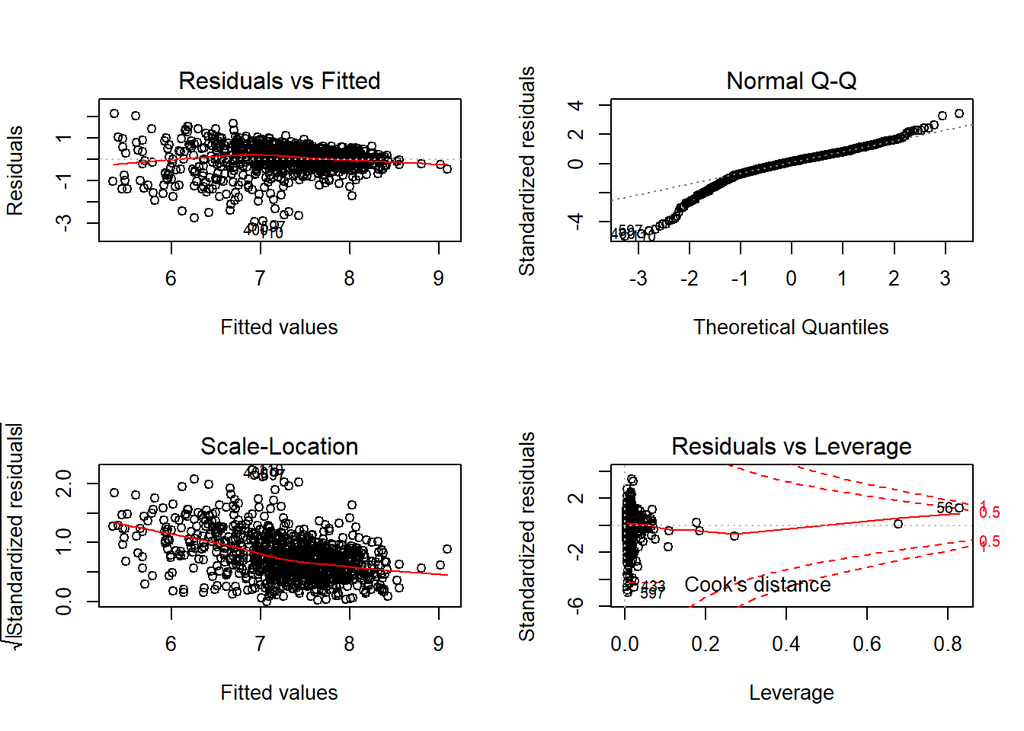

```r
op<-par(mfrow=c(2,2))
plot(m2)
```

```r
par(op)
```

## Fitting the complete model

```r
#step(m1, scope = list(lower=m1,upper=m2), direction="both", criterion = "BIC", k=log(940))
```